# Heritability of P. tremuloides phenology variables

Shannon Hateley, PhD

Spring 2022

This analysis is part of the study by Dr. Ben Blonder et al. on how “legacy effects of drought, heat, and snowmelt interact with cytotype and sex to determine phenology in quaking aspen (Populus tremuloides).”

Also though, this is using only the initial set of environtmental variables. In the final analysis we also look at snowmelt, etc. These variables remain the same but are a subset of the final results.

## Main Analysis

**In short**:  
We obtained measurements of the phenological variables *OGI* (greenup date), *OGMn* (greendown date), *GSL* (growing season length), and *EVImax* (peak greenness) over a four year period. After initial quality checks and filtering, heritability estimates of these variables were made in a two-step process:

1. Control for the confounding effects of environmental covariates using a linear regression
2. Estimate heritability (the proportion of phenotypic variance explained by genetic variance) of the residual effects remaining after regression from step 1 using a genomic restricted maximum likelihood estimation (gREML)

### Methods

#### Heritability estimation

**Software**: Genome-wide Complex Trait Analysis (GCTA) version 1.94.0 beta Linux

Samples were subset to the 488 with genotype information. From these, we generated a genetic relatedness matrix using the 13,680 high-quality variants from the RAD-Seq data aligned to the assembled RAD-Seq contigs and filtered to variants with an allele frequency >= 0.5%. This resulted in 6,173 valid markers for the relatedness calculation. GCTA’s GREML was run on the sample subsets, in one iteration using the residuals as the phenotype and in another using the full phenology variable measurements.

### Results

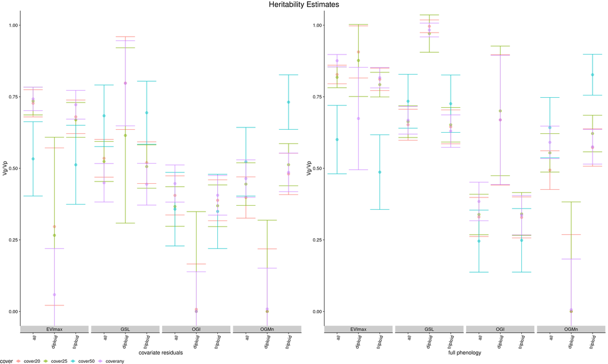

**Results discussion:**

*fraction aspen value*  
I have not thresholded the samples to >50% aspen fraction in the Sentinel-2 pixel, due to number of sample constraints (see histogram below). Note that when regressing on the covariates I have used the subset of each aspen fraction that is used in the heritability estimate.

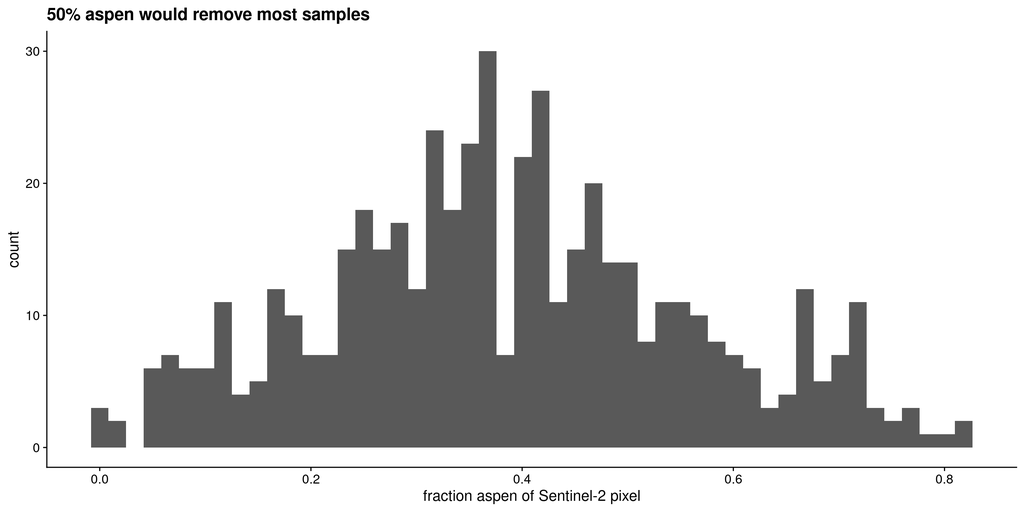

## Data preparation, quality checks, and filtering

##### Correlation between variables

Phenology metrics measurements across years showed strong correlation. Environmental covariates showed varying degrees of correlation to each other and with phenologies, inline with what would be expected based upon their physical and biological relationships to each other.

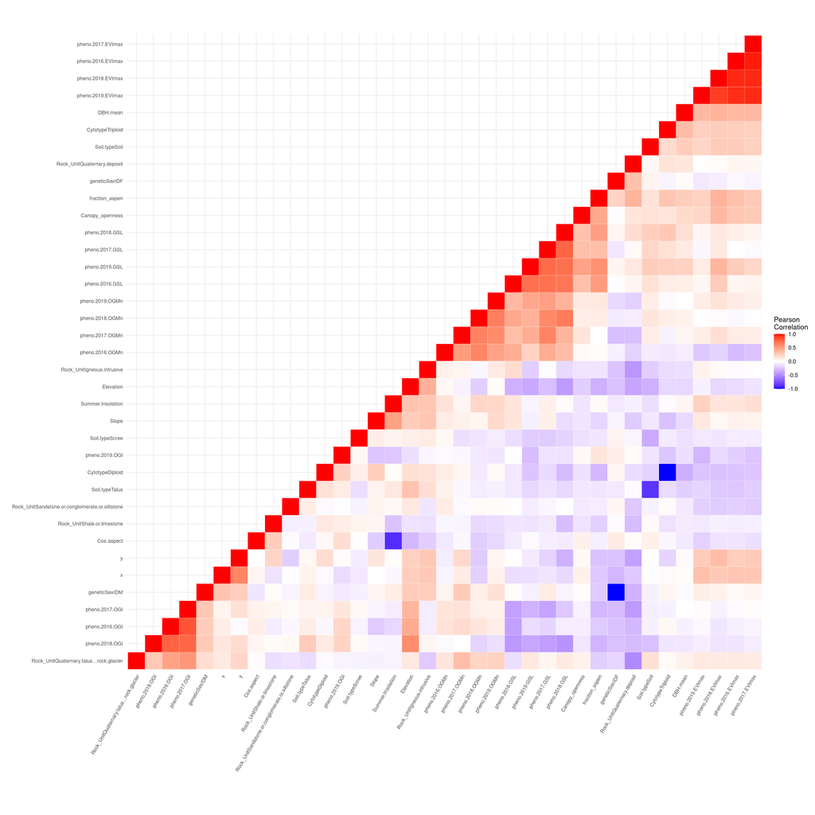

##### Normality of variables

To check if our covariates and continuous phenology variableswere normally distributed (didn’t really need to do, but why not?), we utilized Shapiro-Wilk test and visual inspection of data.

Most of the covariates look fairly normally distributed. However, Cosine Aspect is right-skewed (Shipiro=0.78).

**Covariates**

| variable | Shapiro_Wilk_stat | pval |
| --- | --- | --- |
| Elevation | 0.926113841224978 | 5.022001e-15 |
| Cos.aspect | 0.775722402165348 | 1.133298e-25 |
| Slope | 0.997641523830378 | 7.066382e-01 |
| Summer.Insolation | 0.926765817448147 | 5.936960e-15 |
| DBH.mean | 0.995627039099187 | 1.733522e-01 |
| fraction_aspen | 0.989544199068958 | 1.194590e-03 |

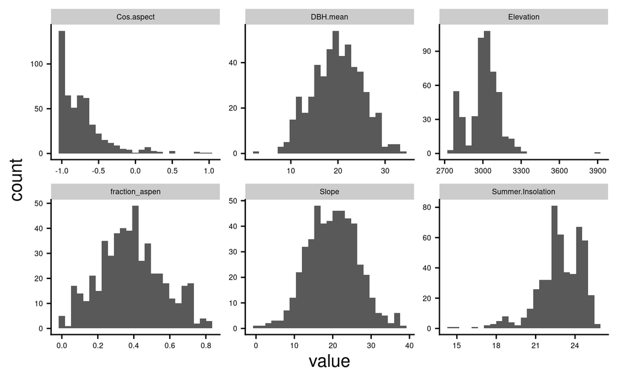

**Phenology variables**

The phenology measurements appear fairly normal-ish:

| variable | Shapiro_Wilk_stat | pval |
| --- | --- | --- |
| pheno.2016.OGI | 0.98096548165743 | 8.032336e-05 |
| pheno.2016.OGMn | 0.886642450822459 | 5.821877e-18 |
| pheno.2016.EVImax | 0.867884277215922 | 3.238045e-20 |
| pheno.2016.GSL | 0.95200898055417 | 2.111460e-09 |
| pheno.2017.OGI | 0.972093056645957 | 3.410003e-06 |
| pheno.2017.OGMn | 0.940946666363614 | 4.503797e-13 |
| pheno.2017.EVImax | 0.883368682183275 | 4.945757e-19 |
| pheno.2017.GSL | 0.96190220698347 | 8.898676e-08 |
| pheno.2018.OGI | 0.989346878605506 | 1.181285e-03 |
| pheno.2018.OGMn | 0.978213374030022 | 1.121269e-06 |

[output cut: 6 more lines]

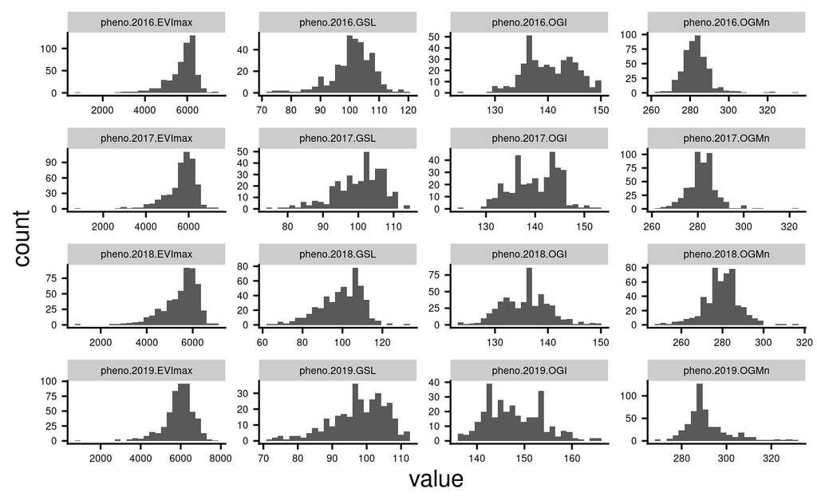

#### Outliers

We performed a preliminary basic check for sample outliers through PCA. First, by visual inspection of first 2 PCs and then through asking if any outliers are 6sd away from mean (this distance however is somewhat arbitrary however often used in genetics). We could do a more rebust outlier check if we wanted but probably not necessary.

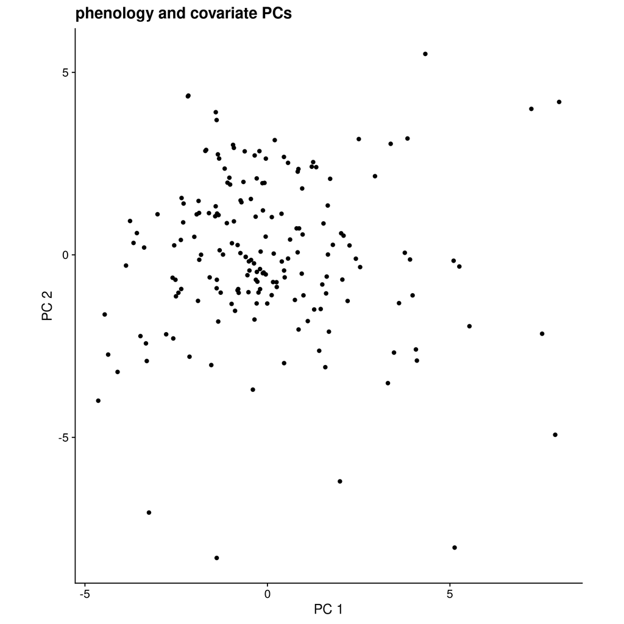

```r
apply(U, 2, function(x) which( abs(x - mean(x)) > (6 * sd(x)) )) #> 6sd from mean
```

```
integer(0)
```

#### Genetic relatedness of samples

To broadly ascertain the extent of population structure in our samples, we generated a kinship matrix of our 488 genotyped samples. We can see a division of population along PC2, which in previous analysis we performed found to be an outlier population of triploids (see plot Moi made back in fall 2021). If we wanted to dive deeper into issues with heritability estimates, it would be useful to look at how phenology values vary in relation to geographic distance and the split we are seeing in this kinship PCA.

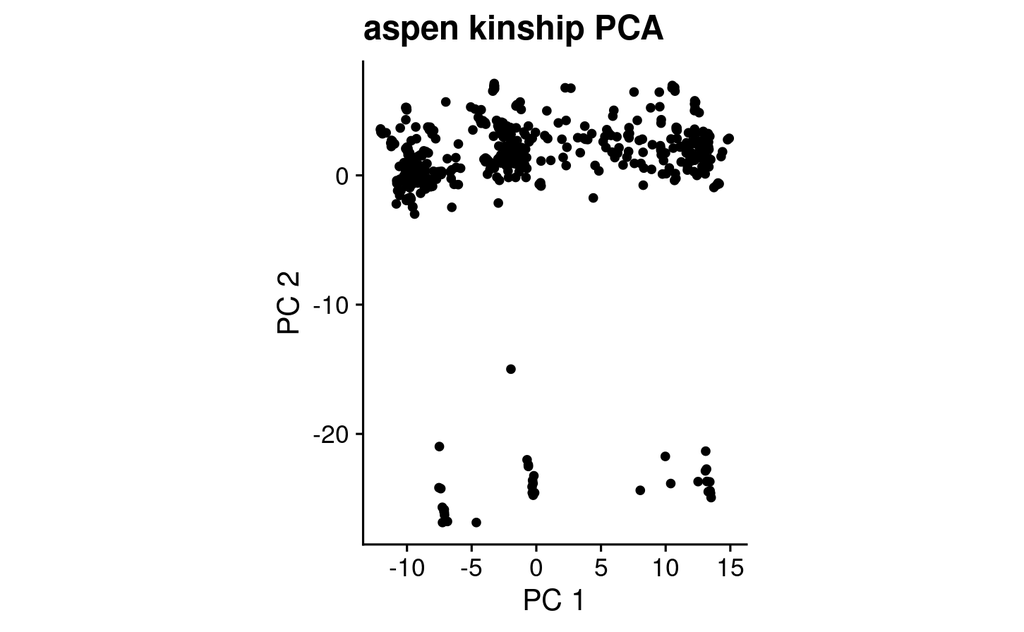

```
Importance of first k=10 (out of 488) components:
                          PC1    PC2     PC3     PC4     PC5     PC6     PC7     PC8
Standard deviation     8.4750 7.0451 6.49592 6.17868 5.42848 4.81805 4.70444 4.33192
Proportion of Variance 0.1472 0.1017 0.08647 0.07823 0.06039 0.04757 0.04535 0.03845
Cumulative Proportion  0.1472 0.2489 0.33536 0.41359 0.47398 0.52155 0.56690 0.60535
                          PC9    PC10
Standard deviation     3.8455 3.64892
Proportion of Variance 0.0303 0.02728
Cumulative Proportion  0.6357 0.66294
```

That’s it for an initial analysis. It is best to keep in mind that the heritability estimates apply to this set of samples in this particular population and might not reflect heritability of phenology in other populations.